# Multiomic data integration with MOFA2 model

### Consider IGHV status

#### IGHV as a covariate

ANOVA test

```r
LDT <- doublingTime %>% mutate(Factor6 = facTab[match(patID, facTab$sample),]$value,
                               IGHV = as.factor(facTab[match(patID, facTab$sample),]$IGHV)) %>%
  filter(!is.na(Factor6),!is.na(IGHV))

corRes <- car::Anova(lm(log10(doubling.time) ~ Factor6 + IGHV, data = LDT))
corRes
```

```
Anova Table (Type II tests)

Response: log10(doubling.time)
           Sum Sq Df F value    Pr(>F)
Factor6    3.7327  1  18.409 4.951e-05 ***
IGHV       8.3884  1  41.369 8.558e-09 ***
Residuals 16.2217 80
---
Signif. codes:  0 ‘***’ 0.001 ‘**’ 0.01 ‘*’ 0.05 ‘.’ 0.1 ‘ ’ 1
```

#### Only M-CLL

```r
LDT.M <- filter(LDT, IGHV == "M")
corRes.M <- cor.test(log2(LDT.M$doubling.time), LDT.M$Factor6)
corRes.M
```

```
    Pearson's product-moment correlation

data:  log2(LDT.M$doubling.time) and LDT.M$Factor6
t = 3.192, df = 41, p-value = 0.002712
alternative hypothesis: true correlation is not equal to 0
95 percent confidence interval:
 0.1683541 0.6582772
sample estimates:
      cor
0.4461393
```

#### Only U-CLL

```r
LDT.U <- filter(LDT, IGHV == "U")
corRes.U <- cor.test(log2(LDT.U$doubling.time), LDT.U$Factor6)
corRes.U
```

```
    Pearson's product-moment correlation

data:  log2(LDT.U$doubling.time) and LDT.U$Factor6
t = 2.7893, df = 38, p-value = 0.00821
alternative hypothesis: true correlation is not equal to 0
95 percent confidence interval:
 0.1155802 0.6413898
sample estimates:
      cor
0.4122469
```

Scatter plot of correlations, stratified by IGHV

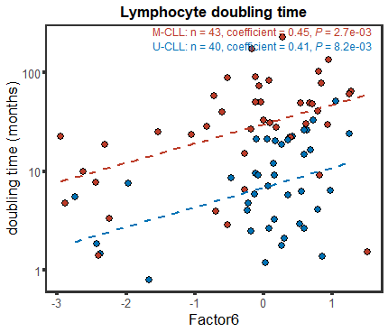

```r
annoM <- sprintf("'M-CLL: n = %s, coefficient = %1.2f,'~italic(P)~'= %s'",nrow(LDT.M), corRes.M$estimate, formatNum(corRes.M$p.value, digits = 1, format = "e"))
annoU <- sprintf("'U-CLL: n = %s, coefficient = %1.2f,'~italic(P)~'= %s'", nrow(LDT.U), corRes.U$estimate,formatNum(corRes.U$p.value, digits = 1, format = "e"))

corPlot.IGHV <- ggplot(LDT, aes(x = Factor6, y = doubling.time/30, fill = IGHV, col = IGHV)) +
  geom_point(shape=21, size=3, col = "black") +
  geom_smooth(method = "lm", se=FALSE, linetype ="dashed" ) +
  annotate("text", x = Inf, y = Inf, label = annoM,
           hjust=1.05, vjust =1.2, size = 4, parse = TRUE, color = colList[1]) +
  annotate("text", x = Inf, y = Inf, label = annoU,
           hjust=1.05, vjust =2.5, size = 4, parse = TRUE, color = colList[2]) +
  ylab("doubling time (months)") + ggtitle("Lymphocyte doubling time") +
  scale_fill_manual(values = c(M = colList[1],U=colList[2])) +
  scale_color_manual(values = c(M = colList[1],U=colList[2])) +
  scale_y_log10() +
  theme_full + theme(legend.position = "none")

corPlot.IGHV
```

Correlations in untreated patients only

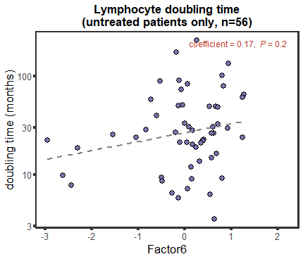

```r
LDT.untreat <- doublingTime %>% mutate(Factor6 = facTab[match(patID, facTab$sample),]$value,
                                       pretreat = demographic[match(patID, demographic$patientID),]$pretreat) %>%
  filter(!is.na(Factor6),!is.na(pretreat)) %>% filter(pretreat == 0)

corRes <- cor.test(LDT.untreat$doubling.time, LDT.untreat$Factor6)

annoText <- sprintf("'coefficient = %1.2f, '~italic(P)~'= %s'",corRes$estimate,formatNum(corRes$p.value, digits = 1, format = "e"))
corPlot.untreat <- ggplot(LDT.untreat, aes(x = Factor6, y = doubling.time/30)) +
  geom_point(fill =colList[5], shape=21, size=3) +
  geom_smooth(method = "lm", se=FALSE, color = "grey50", linetype ="dashed" ) +
  annotate("text", x = 2.2, y = Inf, label = annoText,
           hjust=1, vjust =2, size = 4, parse = TRUE, col= colList[1]) +
  ylab("doubling time (months)") + ggtitle(sprintf("Lymphocyte doubling time\n(untreated patients only, n=%s)",nrow(LDT.untreat))) +
  scale_y_log10() +
  theme_full

corPlot.untreat
```

### Variance expalined for lymphocyte doubling time

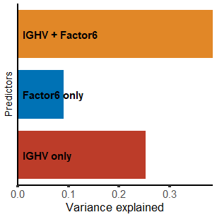

```r
onlyIGHV <- summary(lm(log2(doubling.time) ~ IGHV, data = LDT))
onlyF4 <- summary(lm(log2(doubling.time) ~ Factor6, data = LDT))
combined <- summary(lm(log2(doubling.time) ~ Factor6 + IGHV, data = LDT))
plotTab <- tibble(model = c("IGHV only","Factor6 only", "IGHV + Factor6"),
                  R2 = c(onlyIGHV$adj.r.squared, onlyF4$r.squared, combined$adj.r.squared)) %>%
  mutate(model = factor(model, levels = model))
explainedDT <- ggplot(plotTab, aes(x=model, y = R2)) + geom_bar(stat = "identity", aes(fill = model), width = 0.8) +
  coord_flip(expand = FALSE, xlim = c(0.5,3.5)) + theme_half + scale_fill_manual(values = colList) +
  geom_text(aes(x = model, y =0.01, label = model), hjust =0, fontface = "bold", size =5) +
  theme(axis.ticks.y = element_blank(), axis.text.y = element_blank(), legend.position = "none",
        axis.title.y = element_text( size =13)) +
  xlab("Predictors") + ylab("Variance explained")
explainedDT
```

##Association between F6 and genomics

```r
#Load datasets (MOFA2_CLL, "gene", "rna", "meth", mutLoad", "tabFACS")
```

Process MOFA model

```r
#get factor values
facTab <- get_factors(
  MOFAobject,
  factors = "Factor6",
  as.data.frame = TRUE
) %>% as_tibble()

#get all factors
facTab.all <- get_factors(
  MOFAobject,
  factors = "all",
  as.data.frame = TRUE
) %>% as_tibble()

#get weights
weightTab <- get_weights(
  MOFAobject,
  factors = "all",
  as.data.frame = TRUE
) %>% as_tibble() %>%
  mutate(feature = ifelse(feature == "IGHV.status", "IGHV", feature))
```

###Loading of features in the genomic view

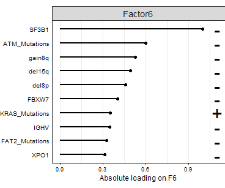

```r
plotGeneWeight <- plot_top_weights(MOFAobject, view =  "Mutations", factor = "Factor6", nfeatures = 10) + ylab("Absolute loading on F6") +
  theme(plot.margin = margin(10,0,10,0))
plotGeneWeight
```

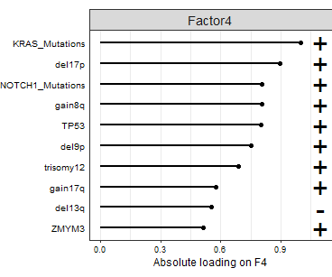

```r
plotGeneWeight <- plot_top_weights(MOFAobject, view =  "Mutations", factor = "Factor4", nfeatures = 10) + ylab("Absolute loading on F4") +
  theme(plot.margin = margin(10,0,10,0))
plotGeneWeight
```

###Test of associations between genetic variations with latent factors Student’s t-test F6

```r
sampleOverlap <- intersect(rownames(gene.unfiltered), facTab$sample)
genData <- gene.unfiltered[sampleOverlap,]
```

```r
#remove gene with higher than 40% missing values
genData <- genData[,colSums(is.na(genData))/nrow(genData) <= 0.4]

#remove genes with less than 3 mutated cases
genData <- genData[,colSums(genData, na.rm = TRUE) >= 3]

#t-test
y <- facTab[match(sampleOverlap, facTab$sample),]$value
tRes <- apply(genData, 2, function(x) {
  res <- t.test(y ~ as.factor(x), var.equal = TRUE)
  data.frame(p = res$p.value,
             df = res$estimate[[2]] - res$estimate[[1]])
}) %>% bind_rows() %>% mutate(gene = colnames(genData),
                              p.adj = p.adjust(p, method = "BH")) %>%
  arrange(p)
filter(tRes, p.adj <0.05) %>% mutate_if(is.numeric, formatNum, digits =3, format = "e") %>% DT::datatable()
```

|  | p | df | gene | p.adj |
| --- | --- | --- | --- | --- |
| 1 | 2.542e-09 | -1.048e+00 | SF3B1 | 1.652e-07 |
| 2 | 1.827e-04 | -2.168e+00 | gain1q | 5.939e-03 |
| 3 | 1.018e-03 | -1.911e+00 | del21q | 0.0221 |
| 4 | 1.983e-03 | -7.723e-01 | ATM | 0.0322 |

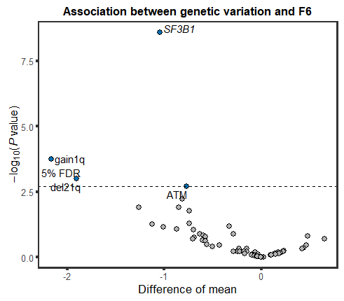

```r
#Volcano plot
plotGeneVolcano <- plotVolcano(tRes, posCol = colList[1], negCol = colList[2],
            x_lab = "Difference of mean", ifLabel = TRUE) +
  ggtitle("Association between genetic variation and F6") +
  theme(legend.position = "none",
        plot.margin = margin(8,8,8,8),
        axis.title.y = element_text(vjust=0))
plotGeneVolcano
```

Student’s t-test F4

```r
#get factor values
facTab <- get_factors(
  MOFAobject,
  factors = "Factor4",
  as.data.frame = TRUE
) %>% as_tibble()
```

```r
sampleOverlap <- intersect(rownames(gene.unfiltered), facTab$sample)
genData <- gene.unfiltered[sampleOverlap,]

#remove gene with higher than 40% missing values
genData <- genData[,colSums(is.na(genData))/nrow(genData) <= 0.4]

#remove genes with less than 3 mutated cases
genData <- genData[,colSums(genData, na.rm = TRUE) >= 3]

#t-test
y <- facTab[match(sampleOverlap, facTab$sample),]$value
tRes <- apply(genData, 2, function(x) {
  res <- t.test(y ~ as.factor(x), var.equal = TRUE)
  data.frame(p = res$p.value,
             df = res$estimate[[2]] - res$estimate[[1]])
}) %>% bind_rows() %>% mutate(gene = colnames(genData),
                              p.adj = p.adjust(p, method = "BH")) %>%
  arrange(p)
filter(tRes, p.adj <0.05) %>% mutate_if(is.numeric, formatNum, digits =3, format = "e") %>% DT::datatable()
```

|  | p | df | gene | p.adj |
| --- | --- | --- | --- | --- |
| 1 | 9.406e-06 | 1.3 | KRAS | 6.114e-04 |
| 2 | 4.541e-04 | 1.7 | del7q | 0.0147 |
| 3 | 9.673e-04 | 1.06 | del9p | 0.0147 |
| 4 | 1.068e-03 | 0.606 | del17p | 0.0147 |
| 5 | 1.134e-03 | 0.811 | gain8q | 0.0147 |
| 6 | 2.031e-03 | 0.58 | NOTCH1 | 0.022 |

Volcano plot

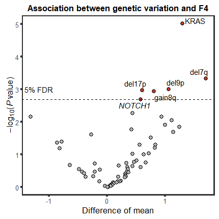

```r
plotGeneVolcano <- plotVolcano(tRes, posCol = colList[1], negCol = colList[2],
            x_lab = "Difference of mean", ifLabel = TRUE) +
  ggtitle("Association between genetic variation and F4") +
  theme(legend.position = "none",
        plot.margin = margin(8,8,8,8),
        axis.title.y = element_text(vjust=0))
plotGeneVolcano
```

Heatmap plot showing associated genetic features (5% FDR), arranged by F6 values.

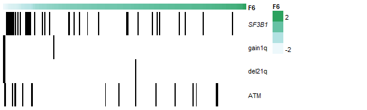

```r
library(pheatmap)
library(grid)
annoCol <- data.frame(row.names = sampleOverlap,
                      F6 = facTab[match(sampleOverlap, facTab$sample),]$value)
annoCol <- annoCol[order(annoCol$F6),,drop = FALSE]
plotMat <- t(genData[rownames(annoCol),filter(tRes, p.adj <= 0.05)$gene])
plotMat[is.na(plotMat)] <- 0
breaks <- c(0,0.5,1)
colors <- c("white","black")
rowLabs <- italicizeGene(rownames(plotMat))
plotGeneHeatmap <- pheatmap(plotMat, cluster_cols = FALSE, cluster_rows = FALSE,
                            annotation_col = annoCol, border_color = "black",
         breaks = breaks, color = colors, show_colnames = FALSE,
         labels_row = parse(text = rowLabs),
         legend = FALSE, silent = TRUE)$gtable
plot_grid(plotGeneHeatmap)
```

Heatmap plot showing associated genetic features (5% FDR), arranged by F4 values.

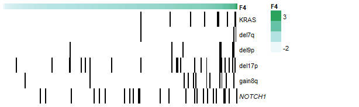

```r
annoCol <- data.frame(row.names = sampleOverlap,
                      F4 = facTab[match(sampleOverlap, facTab$sample),]$value)
annoCol <- annoCol[order(annoCol$F4),,drop = FALSE]
plotMat <- t(genData[rownames(annoCol),filter(tRes, p.adj <= 0.05)$gene])
plotMat[is.na(plotMat)] <- 0
breaks <- c(0,0.5,1)
colors <- c("white","black")
rowLabs <- italicizeGene(rownames(plotMat))
plotGeneHeatmap <- pheatmap(plotMat, cluster_cols = FALSE, cluster_rows = FALSE,
                            annotation_col = annoCol, border_color = "black",
         breaks = breaks, color = colors, show_colnames = FALSE,
         labels_row = parse(text = rowLabs),
         legend = FALSE, silent = TRUE)$gtable
plot_grid(plotGeneHeatmap)
```

##Assocation between F4/F6 and DNA methylation ###Correlation test using linear model

```r
library(limma)
methMat <- assays(meth[,colnames(meth) %in% facTab$sample])[["beta"]]
factorMatrix <- facTab.all %>% spread(key = factor, value = value) %>%
  data.frame() %>% column_to_rownames("sample")
factorMatrix <- factorMatrix[colnames(methMat),]
factorMatrix <- factorMatrix[,complete.cases(t(factorMatrix))]
factorMatrix <- factorMatrix[,-1] #delete column
designMat <- model.matrix(~1 + .,factorMatrix)
fit <- lmFit(methMat, designMat)
fit2 <- eBayes(fit)
corRes <- limma::topTable(fit2, number ="all", coef = "Factor6", adjust.method = "BH") %>%
  rownames_to_column("id") %>% as_tibble()
corRes.LF4 <- limma::topTable(fit2, number ="all", coef = "Factor4", adjust.method = "BH") %>%
  rownames_to_column("id") %>% as_tibble()
```

```r
#Number of tested associations
dim(methMat)
```

```
[1] 394735    158
```

###Compare number of significant correlations in F4 and F6

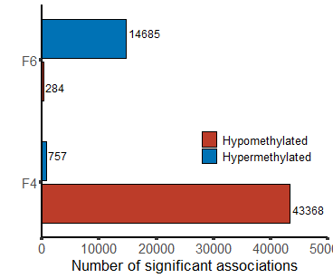

```r
numTab.LF6 <- filter(corRes, adj.P.Val <= 0.01) %>% mutate(direction = ifelse(t>0, "pos","neg")) %>%
  group_by(direction) %>% summarise(number = length(id)) %>%
  mutate(factor = "F6")
numTab.LF4 <- filter(corRes.LF4, adj.P.Val <= 0.01) %>% mutate(direction = ifelse(t>0, "pos","neg")) %>%
  group_by(direction) %>% summarise(number = length(id)) %>%
  mutate(factor = "F4")

plotTab <- bind_rows(numTab.LF4, numTab.LF6)
sigNumPlot <- ggplot(plotTab, aes(x=factor, y=number, fill = direction)) +
  geom_bar(stat = "identity", width = 0.7,
           position = position_dodge2(width = 6),
           col = "black") +
  geom_text(aes(label=number),
            position = position_dodge(width = 0.9),
            size=4, hjust=-0.1)  +
  scale_fill_manual(name = "", labels = c("Hypomethylated","Hypermethylated"), values = colList) +
  coord_flip(ylim = c(0,50000), expand = FALSE) + xlab("") + ylab("Number of significant associations") + theme_half +
  theme(legend.position = c(0.75,0.42), legend.text = element_text(size=12), legend.background = element_rect(fill = NA))
sigNumPlot
```

Correlation between mean methylation values and F6

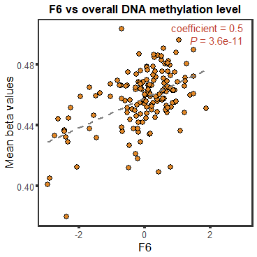

```r
meanBeta <- colMeans(methMat)
plotTab <- tibble(patID = names(meanBeta),
                  meanBeta = meanBeta,
                  F6 = facTab[match(patID, facTab$sample),]$value)

corBeta <- cor.test(plotTab$meanBeta, plotTab$F6)

annoCoef <- paste("'coefficient ='~",format(corBeta$estimate,digits = 2))
annoP <- paste("italic(P)~'='~",formatNum(corBeta$p.value, digits = 1, format = "e"))

plotMeanBeta <- ggplot(plotTab, aes(x = F6, y = meanBeta)) +
  geom_point(shape = 21, fill =colList[3], size=3) +
  geom_smooth(method = "lm", se=FALSE, color = "grey50", linetype ="dashed" ) +
  annotate("text", x = 3, y = Inf, label = annoCoef,
           hjust=1, vjust =1.5, size = 5, parse = TRUE, col= colList[1]) +
  annotate("text", x = 3, y = Inf, label = annoP,
           hjust=1, vjust =3, size = 5, parse = TRUE, col= colList[1]) +
  ylab("Mean beta values") + xlab("F6") +
  ggtitle("F6 vs overall DNA methylation level") +
  theme_full

plotMeanBeta
```

Correlation between mean methylation values and F4

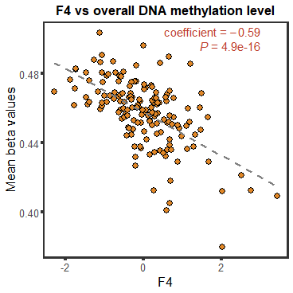

```r
#get factor values
facTab <- get_factors(
  MOFAobject,
  factors = "Factor4",
  as.data.frame = TRUE
) %>% as_tibble()

meanBeta <- colMeans(methMat)
plotTab <- tibble(patID = names(meanBeta),
                  meanBeta = meanBeta,
                  F4 = facTab[match(patID, facTab$sample),]$value)

corBeta <- cor.test(plotTab$meanBeta, plotTab$F4)

annoCoef <- paste("'coefficient ='~",format(corBeta$estimate,digits = 2))
annoP <- paste("italic(P)~'='~",formatNum(corBeta$p.value, digits = 1, format = "e"))

plotMeanBeta <- ggplot(plotTab, aes(x = F4, y = meanBeta)) +
  geom_point(shape = 21, fill =colList[3], size=3) +
  geom_smooth(method = "lm", se=FALSE, color = "grey50", linetype ="dashed" ) +
  annotate("text", x = 3, y = Inf, label = annoCoef,
           hjust=1, vjust =1.5, size = 5, parse = TRUE, col= colList[1]) +
  annotate("text", x = 3, y = Inf, label = annoP,
           hjust=1, vjust =3, size = 5, parse = TRUE, col= colList[1]) +
  ylab("Mean beta values") + xlab("F4") +
  ggtitle("F4 vs overall DNA methylation level") +
  theme_full

plotMeanBeta
```

##Reactome pathway Enrichment Gsea

```r
#F1 enrichment on positive weights
res.positive <- run_enrichment(MOFAobject,
                               feature.sets = reactomeGS3,
                               view = "mRNA",
                               factor = 1,
                               sign = "positive")
```

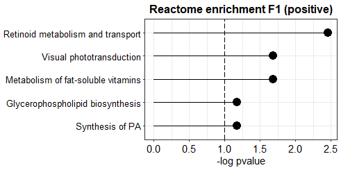

```r
plot_enrichment(res.positive, factor = "Factor1", max.pathways = 20)+ ggtitle("Reactome enrichment F1 (positive)")
```

F1 enrichment on negative weights

```r
res.negative <- run_enrichment(MOFAobject,
                               feature.sets = reactomeGS3,
                               view = "mRNA", factor = 1,
                               sign = "negative")
```

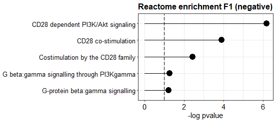

```r
plot_enrichment(res.negative, factor = "Factor1", max.pathways = 10)+ ggtitle("Reactome enrichment F1 (negative)")
```

F2 enrichment on positive weights

```r
res.positive <- run_enrichment(MOFAobject,
                               feature.sets = reactomeGS3,
                               view = "mRNA",
                               factor = 2,
                               sign = "positive")
```

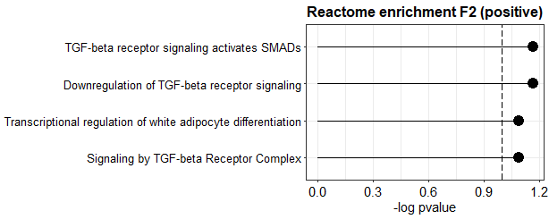

```r
plot_enrichment(res.positive, factor = "Factor2", max.pathways = 20)+ ggtitle("Reactome enrichment F2 (positive)")
```

F2 enrichment on negative weights

```r
res.negative <- run_enrichment(MOFAobject,
                               feature.sets = reactomeGS3,
                               view = "mRNA", factor = 2,
                               sign = "negative")
```

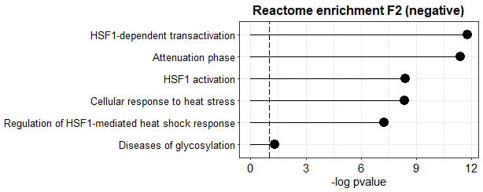

```r
plot_enrichment(res.negative, factor = "Factor2", max.pathways = 10)+ ggtitle("Reactome enrichment F2 (negative)")
```

F3 enrichment on positive weights

```r
res.positive <- run_enrichment(MOFAobject,
                               feature.sets = reactomeGS3,
                               view = "mRNA",
                               factor = 3,
                               sign = "positive")
```

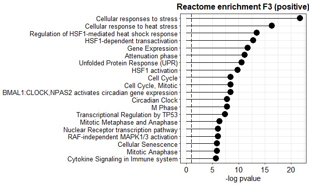

```r
plot_enrichment(res.positive, factor = "Factor3", max.pathways = 20)+ ggtitle("Reactome enrichment F3 (positive)")
```

F3 enrichment on negative weights

```r
res.negative <- run_enrichment(MOFAobject,
                               feature.sets = reactomeGS3,
                               view = "mRNA", factor = 3,
                               sign = "negative")
```

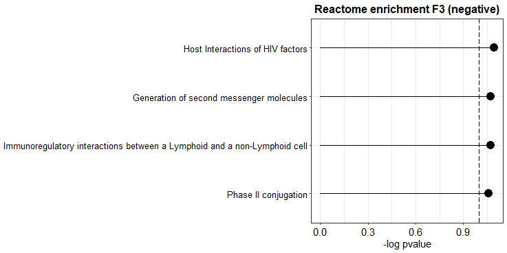

```r
plot_enrichment(res.negative, factor = "Factor3", max.pathways = 10)+ ggtitle("Reactome enrichment F3 (negative)")
```

F4 enrichment on positive weights

```r
res.positive <- run_enrichment(MOFAobject,
                               feature.sets = reactomeGS3,
                               view = "mRNA",
                               factor = 4,
                               sign = "positive")
```

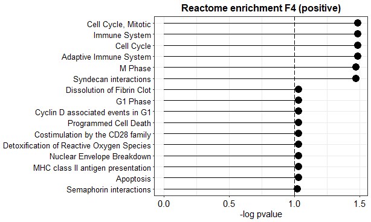

```r
plot_enrichment(res.positive, factor = "Factor4", max.pathways = 20)+ ggtitle("Reactome enrichment F4 (positive)")
```

F4 enrichment on negative weights

```r
res.negative <- run_enrichment(MOFAobject,
                               feature.sets = reactomeGS3,
                               view = "mRNA", factor = 4,
                               sign = "negative")
```

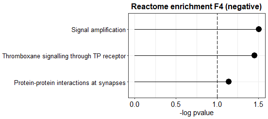

```r
plot_enrichment(res.negative, factor = "Factor4", max.pathways = 20)+ ggtitle("Reactome enrichment F4 (negative)")
```

F6 enrichment on positive weights

```r
res.positive <- run_enrichment(MOFAobject,
                               feature.sets = reactomeGS3,
                               view = "mRNA",
                               factor = 6,
                               sign = "positive")
```

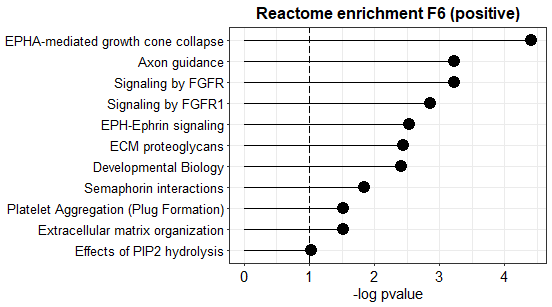

```r
plot_enrichment(res.positive, factor = "Factor6", max.pathways = 20)+ ggtitle("Reactome enrichment F6 (positive)")
```

F7 enrichment on positive weights

```r
res.positive <- run_enrichment(MOFAobject,
                               feature.sets = reactomeGS3,
                               view = "mRNA",
                               factor = 7,
                               sign = "positive")
```

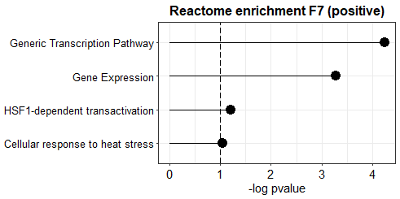

```r
plot_enrichment(res.positive, factor = "Factor7", max.pathways = 20)+ ggtitle("Reactome enrichment F7 (positive)")
```

F7 enrichment on negative weights

```r
res.negative <- run_enrichment(MOFAobject,
                               feature.sets = reactomeGS3,
                               view = "mRNA", factor = 7,
                               sign = "negative")
```

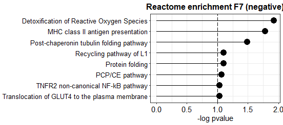

```r
plot_enrichment(res.negative, factor = "Factor7", max.pathways = 20)+ ggtitle("Reactome enrichment F7 (negative)")
```

F8 enrichment on positive weights

```r
res.positive <- run_enrichment(MOFAobject,
                               feature.sets = reactomeGS3,
                               view = "mRNA",
                               factor = 8,
                               sign = "positive")
```

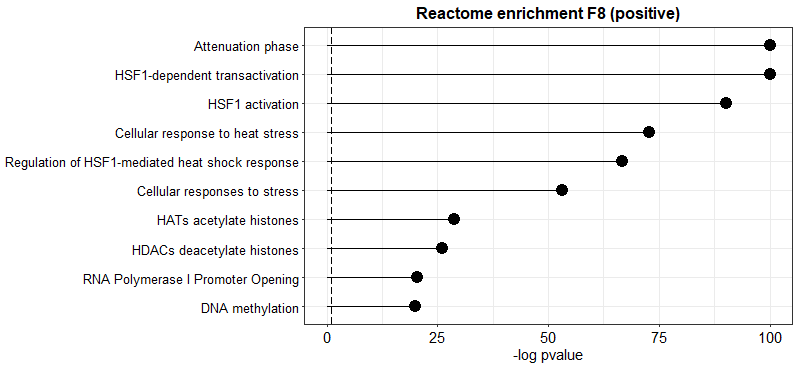

```r
plot_enrichment(res.positive, factor = "Factor8", max.pathways = 10)+ ggtitle("Reactome enrichment F8 (positive)")
```

F8 enrichment on negative weights

```r
res.negative <- run_enrichment(MOFAobject,
                               feature.sets = reactomeGS3,
                               view = "mRNA", factor = 8,
                               sign = "negative")
```

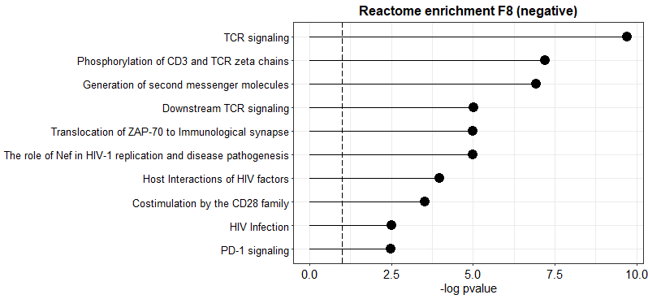

```r
plot_enrichment(res.negative, factor = "Factor8", max.pathways = 10)+ ggtitle("Reactome enrichment F8 (negative)")
```